# Risk Factor Analysis

## Outcome Variable

**Outcome Variable:** swasted

## Predictor Variables

**Intervention Variable:** feducyrs

**Adjustment Set:**

unadjusted

## Stratifying Variables

The analysis was stratified on these variable(s):

- agecat
- studyid
- country

## Data Summary

| agecat | studyid | country | feducyrs | swasted | n_cell | n |
| --- | --- | --- | --- | --- | --- | --- |
| Birth | COHORTS | GUATEMALA | High | 0 | 125 | 718 |
| Birth | COHORTS | GUATEMALA | High | 1 | 11 | 718 |
| Birth | COHORTS | GUATEMALA | Low | 0 | 287 | 718 |
| Birth | COHORTS | GUATEMALA | Low | 1 | 24 | 718 |
| Birth | COHORTS | GUATEMALA | Medium | 0 | 252 | 718 |
| Birth | COHORTS | GUATEMALA | Medium | 1 | 19 | 718 |
| Birth | COHORTS | INDIA | High | 0 | 481 | 1291 |
| Birth | COHORTS | INDIA | High | 1 | 26 | 1291 |
| Birth | COHORTS | INDIA | Low | 0 | 407 | 1291 |
| Birth | COHORTS | INDIA | Low | 1 | 7 | 1291 |
| Birth | COHORTS | INDIA | Medium | 0 | 349 | 1291 |
| Birth | COHORTS | INDIA | Medium | 1 | 21 | 1291 |
| Birth | COHORTS | PHILIPPINES | High | 0 | 945 | 2728 |
| Birth | COHORTS | PHILIPPINES | High | 1 | 49 | 2728 |
| Birth | COHORTS | PHILIPPINES | Low | 0 | 753 | 2728 |
| Birth | COHORTS | PHILIPPINES | Low | 1 | 20 | 2728 |
| Birth | COHORTS | PHILIPPINES | Medium | 0 | 919 | 2728 |
| Birth | COHORTS | PHILIPPINES | Medium | 1 | 42 | 2728 |
| Birth | GMS-Nepal | NEPAL | High | 0 | 151 | 640 |
| Birth | GMS-Nepal | NEPAL | High | 1 | 11 | 640 |
| Birth | GMS-Nepal | NEPAL | Low | 0 | 259 | 640 |
| Birth | GMS-Nepal | NEPAL | Low | 1 | 7 | 640 |
| Birth | GMS-Nepal | NEPAL | Medium | 0 | 203 | 640 |
| Birth | GMS-Nepal | NEPAL | Medium | 1 | 9 | 640 |
| Birth | JiVitA-3 | BANGLADESH | High | 0 | 3965 | 17367 |
| Birth | JiVitA-3 | BANGLADESH | High | 1 | 84 | 17367 |
| Birth | JiVitA-3 | BANGLADESH | Low | 0 | 7312 | 17367 |
| Birth | JiVitA-3 | BANGLADESH | Low | 1 | 140 | 17367 |
| Birth | JiVitA-3 | BANGLADESH | Medium | 0 | 5760 | 17367 |
| Birth | JiVitA-3 | BANGLADESH | Medium | 1 | 106 | 17367 |

[output cut: 300 more lines]

The following strata were considered:

- agecat: 24 months, studyid: COHORTS, country: GUATEMALA
- agecat: 24 months, studyid: COHORTS, country: INDIA
- agecat: 24 months, studyid: COHORTS, country: PHILIPPINES
- agecat: 24 months, studyid: GMS-Nepal, country: NEPAL
- agecat: 24 months, studyid: JiVitA-3, country: BANGLADESH
- agecat: 24 months, studyid: JiVitA-4, country: BANGLADESH
- agecat: 24 months, studyid: LCNI-5, country: MALAWI
- agecat: 24 months, studyid: MAL-ED, country: BANGLADESH
- agecat: 24 months, studyid: MAL-ED, country: INDIA
- agecat: 24 months, studyid: MAL-ED, country: NEPAL
- agecat: 24 months, studyid: MAL-ED, country: PERU
- agecat: 24 months, studyid: MAL-ED, country: SOUTH AFRICA
- agecat: 24 months, studyid: MAL-ED, country: TANZANIA, UNITED REPUBLIC OF
- agecat: 24 months, studyid: NIH-Crypto, country: BANGLADESH
- agecat: 24 months, studyid: PROBIT, country: BELARUS
- agecat: 24 months, studyid: PROVIDE, country: BANGLADESH
- agecat: 24 months, studyid: TanzaniaChild2, country: TANZANIA, UNITED REPUBLIC OF
- agecat: 24 months, studyid: ZVITAMBO, country: ZIMBABWE
- agecat: 6 months, studyid: COHORTS, country: GUATEMALA
- agecat: 6 months, studyid: COHORTS, country: INDIA
- agecat: 6 months, studyid: COHORTS, country: PHILIPPINES
- agecat: 6 months, studyid: GMS-Nepal, country: NEPAL
- agecat: 6 months, studyid: JiVitA-3, country: BANGLADESH
- agecat: 6 months, studyid: JiVitA-4, country: BANGLADESH
- agecat: 6 months, studyid: LCNI-5, country: MALAWI
- agecat: 6 months, studyid: MAL-ED, country: BANGLADESH
- agecat: 6 months, studyid: MAL-ED, country: INDIA
- agecat: 6 months, studyid: MAL-ED, country: NEPAL
- agecat: 6 months, studyid: MAL-ED, country: PERU
- agecat: 6 months, studyid: MAL-ED, country: SOUTH AFRICA
- agecat: 6 months, studyid: MAL-ED, country: TANZANIA, UNITED REPUBLIC OF
- agecat: 6 months, studyid: NIH-Crypto, country: BANGLADESH
- agecat: 6 months, studyid: PROBIT, country: BELARUS
- agecat: 6 months, studyid: PROVIDE, country: BANGLADESH
- agecat: 6 months, studyid: SAS-CompFeed, country: INDIA
- agecat: 6 months, studyid: SAS-FoodSuppl, country: INDIA
- agecat: 6 months, studyid: TanzaniaChild2, country: TANZANIA, UNITED REPUBLIC OF
- agecat: 6 months, studyid: ZVITAMBO, country: ZIMBABWE
- agecat: Birth, studyid: COHORTS, country: GUATEMALA
- agecat: Birth, studyid: COHORTS, country: INDIA
- agecat: Birth, studyid: COHORTS, country: PHILIPPINES
- agecat: Birth, studyid: GMS-Nepal, country: NEPAL
- agecat: Birth, studyid: JiVitA-3, country: BANGLADESH
- agecat: Birth, studyid: JiVitA-4, country: BANGLADESH
- agecat: Birth, studyid: MAL-ED, country: BANGLADESH
- agecat: Birth, studyid: MAL-ED, country: INDIA
- agecat: Birth, studyid: MAL-ED, country: NEPAL
- agecat: Birth, studyid: MAL-ED, country: PERU
- agecat: Birth, studyid: MAL-ED, country: SOUTH AFRICA
- agecat: Birth, studyid: MAL-ED, country: TANZANIA, UNITED REPUBLIC OF
- agecat: Birth, studyid: NIH-Crypto, country: BANGLADESH
- agecat: Birth, studyid: PROBIT, country: BELARUS
- agecat: Birth, studyid: PROVIDE, country: BANGLADESH
- agecat: Birth, studyid: SAS-CompFeed, country: INDIA
- agecat: Birth, studyid: ZVITAMBO, country: ZIMBABWE

### Dropped Strata

Some strata were dropped due to rare outcomes:

- agecat: Birth, studyid: MAL-ED, country: BANGLADESH
- agecat: Birth, studyid: MAL-ED, country: INDIA
- agecat: Birth, studyid: MAL-ED, country: NEPAL
- agecat: Birth, studyid: MAL-ED, country: PERU
- agecat: Birth, studyid: MAL-ED, country: SOUTH AFRICA
- agecat: Birth, studyid: MAL-ED, country: TANZANIA, UNITED REPUBLIC OF
- agecat: Birth, studyid: PROVIDE, country: BANGLADESH
- agecat: 6 months, studyid: COHORTS, country: GUATEMALA
- agecat: 6 months, studyid: GMS-Nepal, country: NEPAL
- agecat: 6 months, studyid: JiVitA-4, country: BANGLADESH
- agecat: 6 months, studyid: LCNI-5, country: MALAWI
- agecat: 6 months, studyid: MAL-ED, country: BANGLADESH
- agecat: 6 months, studyid: MAL-ED, country: INDIA
- agecat: 6 months, studyid: MAL-ED, country: NEPAL
- agecat: 6 months, studyid: MAL-ED, country: PERU
- agecat: 6 months, studyid: MAL-ED, country: SOUTH AFRICA
- agecat: 6 months, studyid: MAL-ED, country: TANZANIA, UNITED REPUBLIC OF
- agecat: 6 months, studyid: NIH-Crypto, country: BANGLADESH
- agecat: 6 months, studyid: PROBIT, country: BELARUS
- agecat: 6 months, studyid: PROVIDE, country: BANGLADESH
- agecat: 6 months, studyid: TanzaniaChild2, country: TANZANIA, UNITED REPUBLIC OF
- agecat: 24 months, studyid: COHORTS, country: GUATEMALA
- agecat: 24 months, studyid: COHORTS, country: INDIA
- agecat: 24 months, studyid: COHORTS, country: PHILIPPINES
- agecat: 24 months, studyid: GMS-Nepal, country: NEPAL
- agecat: 24 months, studyid: LCNI-5, country: MALAWI
- agecat: 24 months, studyid: MAL-ED, country: BANGLADESH
- agecat: 24 months, studyid: MAL-ED, country: INDIA
- agecat: 24 months, studyid: MAL-ED, country: NEPAL
- agecat: 24 months, studyid: MAL-ED, country: PERU
- agecat: 24 months, studyid: MAL-ED, country: SOUTH AFRICA
- agecat: 24 months, studyid: MAL-ED, country: TANZANIA, UNITED REPUBLIC OF
- agecat: 24 months, studyid: NIH-Crypto, country: BANGLADESH
- agecat: 24 months, studyid: PROBIT, country: BELARUS
- agecat: 24 months, studyid: PROVIDE, country: BANGLADESH
- agecat: 24 months, studyid: TanzaniaChild2, country: TANZANIA, UNITED REPUBLIC OF
- agecat: 24 months, studyid: ZVITAMBO, country: ZIMBABWE

## Methods Detail

We’re interested in the causal parameters $E[Y_a]$ for all values of $a \in \mathcal{A}$. These parameters represent the mean outcome if, possibly contrary to fact, we intervened to set all units to have $A=a$. Under the randomization and positivity assumptions, these are identified by the statistical parameters $\psi_a=E_W[E_{Y|A,W}(Y|A=a,W)]$. In addition, we’re interested in the mean of $Y$, $E[Y]$ under no intervention (the observed mean). We will estimate these parameters by using SuperLearner to fit the relevant likelihood factors – $E_{Y|A,W}(Y|A=a,W)$ and $p(A=a|W)$, and then updating our likelihood fit using a joint TMLE.

For unadjusted analyses ($W=\{\}$), initial likelihoods were estimated using Lrnr_glm to estimate the simple $E(Y|A)$ and Lrnr_mean to estimate $p(A)$. For adjusted analyses, a small library containing Lrnr_glmnet, Lrnr_xgboost, and Lrnr_mean was used.

Having estimated these parameters, we will then use the delta method to estimate relative risks and attributable risks relative to a prespecified baseline level of $A$.

# Results Detail

## Results Plots

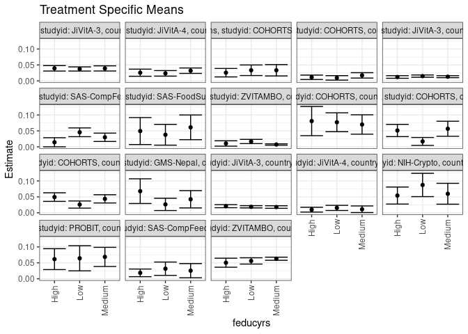

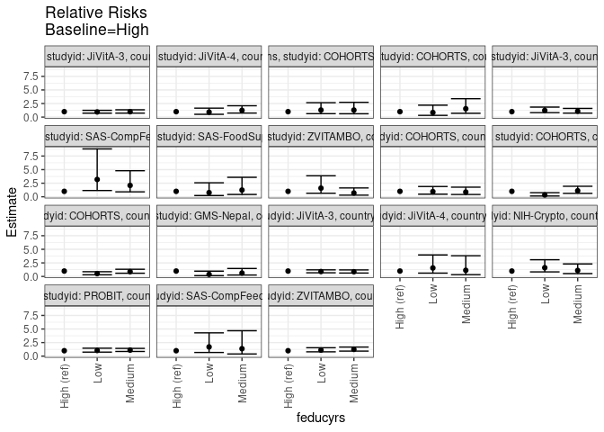

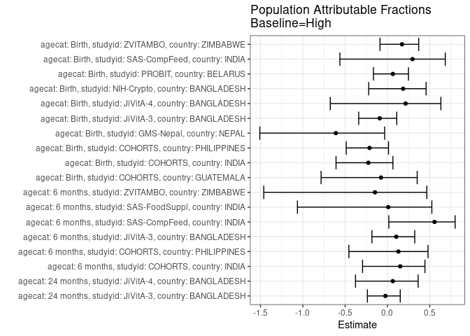

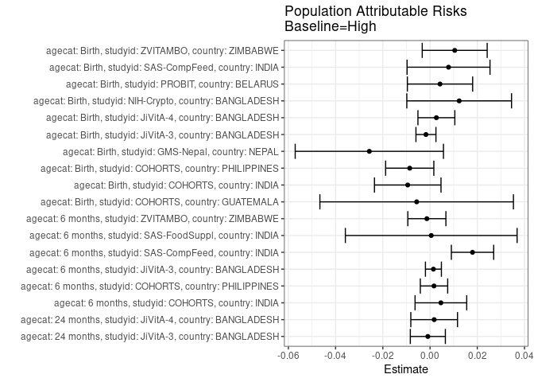

## Results Table

### Parameter: TSM

| agecat | studyid | country | intervention_level | baseline_level | estimate | ci_lower | ci_upper |
| --- | --- | --- | --- | --- | --- | --- | --- |
| Birth | COHORTS | GUATEMALA | High | NA | 0.0808824 | 0.0350266 | 0.1267381 |
| Birth | COHORTS | GUATEMALA | Low | NA | 0.0771704 | 0.0474909 | 0.1068499 |
| Birth | COHORTS | GUATEMALA | Medium | NA | 0.0701107 | 0.0396897 | 0.1005317 |
| Birth | COHORTS | INDIA | High | NA | 0.0512821 | 0.0320749 | 0.0704892 |
| Birth | COHORTS | INDIA | Low | NA | 0.0169082 | 0.0044842 | 0.0293322 |
| Birth | COHORTS | INDIA | Medium | NA | 0.0567568 | 0.0331717 | 0.0803418 |
| Birth | COHORTS | PHILIPPINES | High | NA | 0.0492958 | 0.0358352 | 0.0627563 |
| Birth | COHORTS | PHILIPPINES | Low | NA | 0.0258732 | 0.0146796 | 0.0370669 |
| Birth | COHORTS | PHILIPPINES | Medium | NA | 0.0437045 | 0.0307767 | 0.0566323 |
| Birth | GMS-Nepal | NEPAL | High | NA | 0.0679012 | 0.0291309 | 0.1066716 |
| Birth | GMS-Nepal | NEPAL | Low | NA | 0.0263158 | 0.0070643 | 0.0455673 |
| Birth | GMS-Nepal | NEPAL | Medium | NA | 0.0424528 | 0.0152914 | 0.0696143 |
| Birth | JiVitA-3 | BANGLADESH | High | NA | 0.0207459 | 0.0159485 | 0.0255432 |
| Birth | JiVitA-3 | BANGLADESH | Low | NA | 0.0187869 | 0.0152908 | 0.0222830 |
| Birth | JiVitA-3 | BANGLADESH | Medium | NA | 0.0180702 | 0.0140314 | 0.0221091 |
| Birth | JiVitA-4 | BANGLADESH | High | NA | 0.0098039 | 0.0022932 | 0.0173147 |
| Birth | JiVitA-4 | BANGLADESH | Low | NA | 0.0153341 | 0.0072544 | 0.0234137 |
| Birth | JiVitA-4 | BANGLADESH | Medium | NA | 0.0111111 | 0.0007252 | 0.0214971 |
| Birth | NIH-Crypto | BANGLADESH | High | NA | 0.0541516 | 0.0274811 | 0.0808222 |
| Birth | NIH-Crypto | BANGLADESH | Low | NA | 0.0873362 | 0.0507439 | 0.1239286 |
| Birth | NIH-Crypto | BANGLADESH | Medium | NA | 0.0597015 | 0.0269235 | 0.0924795 |
| Birth | PROBIT | BELARUS | High | NA | 0.0615535 | 0.0287578 | 0.0943491 |
| Birth | PROBIT | BELARUS | Low | NA | 0.0642479 | 0.0248277 | 0.1036681 |
| Birth | PROBIT | BELARUS | Medium | NA | 0.0685410 | 0.0384815 | 0.0986006 |
| Birth | SAS-CompFeed | INDIA | High | NA | 0.0185185 | 0.0065073 | 0.0305297 |
| Birth | SAS-CompFeed | INDIA | Low | NA | 0.0315126 | 0.0105174 | 0.0525078 |
| Birth | SAS-CompFeed | INDIA | Medium | NA | 0.0253521 | 0.0030904 | 0.0476138 |
| Birth | ZVITAMBO | ZIMBABWE | High | NA | 0.0503282 | 0.0361545 | 0.0645020 |
| Birth | ZVITAMBO | ZIMBABWE | Low | NA | 0.0559541 | 0.0461026 | 0.0658056 |
| Birth | ZVITAMBO | ZIMBABWE | Medium | NA | 0.0628135 | 0.0579518 | 0.0676753 |
| 6 months | COHORTS | INDIA | High | NA | 0.0257353 | 0.0124244 | 0.0390462 |
| 6 months | COHORTS | INDIA | Low | NA | 0.0333333 | 0.0167422 | 0.0499245 |
| 6 months | COHORTS | INDIA | Medium | NA | 0.0332481 | 0.0154711 | 0.0510250 |
| 6 months | COHORTS | PHILIPPINES | High | NA | 0.0112108 | 0.0043001 | 0.0181214 |
| 6 months | COHORTS | PHILIPPINES | Low | NA | 0.0094086 | 0.0024703 | 0.0163470 |
| 6 months | COHORTS | PHILIPPINES | Medium | NA | 0.0172786 | 0.0088841 | 0.0256732 |
| 6 months | JiVitA-3 | BANGLADESH | High | NA | 0.0121751 | 0.0080873 | 0.0162629 |
| 6 months | JiVitA-3 | BANGLADESH | Low | NA | 0.0149420 | 0.0114051 | 0.0184788 |
| 6 months | JiVitA-3 | BANGLADESH | Medium | NA | 0.0131698 | 0.0100887 | 0.0162508 |
| 6 months | SAS-CompFeed | INDIA | High | NA | 0.0143266 | 0.0000589 | 0.0285944 |
| 6 months | SAS-CompFeed | INDIA | Low | NA | 0.0456204 | 0.0318281 | 0.0594127 |
| 6 months | SAS-CompFeed | INDIA | Medium | NA | 0.0299539 | 0.0168697 | 0.0430382 |
| 6 months | SAS-FoodSuppl | INDIA | High | NA | 0.0495050 | 0.0071447 | 0.0918652 |
| 6 months | SAS-FoodSuppl | INDIA | Low | NA | 0.0378788 | 0.0052691 | 0.0704884 |
| 6 months | SAS-FoodSuppl | INDIA | Medium | NA | 0.0612245 | 0.0224179 | 0.1000310 |
| 6 months | ZVITAMBO | ZIMBABWE | High | NA | 0.0105448 | 0.0021515 | 0.0189382 |
| 6 months | ZVITAMBO | ZIMBABWE | Low | NA | 0.0167481 | 0.0101035 | 0.0233926 |
| 6 months | ZVITAMBO | ZIMBABWE | Medium | NA | 0.0073436 | 0.0052291 | 0.0094580 |
| 24 months | JiVitA-3 | BANGLADESH | High | NA | 0.0394161 | 0.0308508 | 0.0479813 |
| 24 months | JiVitA-3 | BANGLADESH | Low | NA | 0.0373776 | 0.0308904 | 0.0438649 |
| 24 months | JiVitA-3 | BANGLADESH | Medium | NA | 0.0391121 | 0.0309781 | 0.0472460 |
| 24 months | JiVitA-4 | BANGLADESH | High | NA | 0.0256410 | 0.0144907 | 0.0367914 |
| 24 months | JiVitA-4 | BANGLADESH | Low | NA | 0.0236128 | 0.0149231 | 0.0323024 |
| 24 months | JiVitA-4 | BANGLADESH | Medium | NA | 0.0319383 | 0.0234378 | 0.0404388 |

### Parameter: E(Y)

| agecat | studyid | country | intervention_level | baseline_level | estimate | ci_lower | ci_upper |
| --- | --- | --- | --- | --- | --- | --- | --- |
| Birth | COHORTS | GUATEMALA | NA | NA | 0.0752089 | 0.0559050 | 0.0945128 |
| Birth | COHORTS | INDIA | NA | NA | 0.0418280 | 0.0309034 | 0.0527527 |
| Birth | COHORTS | PHILIPPINES | NA | NA | 0.0406891 | 0.0332739 | 0.0481044 |
| Birth | GMS-Nepal | NEPAL | NA | NA | 0.0421875 | 0.0266017 | 0.0577733 |
| Birth | JiVitA-3 | BANGLADESH | NA | NA | 0.0190016 | 0.0166360 | 0.0213671 |
| Birth | JiVitA-4 | BANGLADESH | NA | NA | 0.0124839 | 0.0071213 | 0.0178464 |
| Birth | NIH-Crypto | BANGLADESH | NA | NA | 0.0664781 | 0.0481022 | 0.0848539 |
| Birth | PROBIT | BELARUS | NA | NA | 0.0657678 | 0.0327531 | 0.0987825 |
| Birth | SAS-CompFeed | INDIA | NA | NA | 0.0263397 | 0.0123159 | 0.0403635 |
| Birth | ZVITAMBO | ZIMBABWE | NA | NA | 0.0607651 | 0.0565891 | 0.0649411 |
| 6 months | COHORTS | INDIA | NA | NA | 0.0303249 | 0.0212906 | 0.0393592 |
| 6 months | COHORTS | PHILIPPINES | NA | NA | 0.0128806 | 0.0085134 | 0.0172477 |
| 6 months | JiVitA-3 | BANGLADESH | NA | NA | 0.0135983 | 0.0114298 | 0.0157667 |
| 6 months | SAS-CompFeed | INDIA | NA | NA | 0.0323065 | 0.0236135 | 0.0409996 |
| 6 months | SAS-FoodSuppl | INDIA | NA | NA | 0.0500000 | 0.0280580 | 0.0719420 |
| 6 months | ZVITAMBO | ZIMBABWE | NA | NA | 0.0091943 | 0.0071366 | 0.0112520 |
| 24 months | JiVitA-3 | BANGLADESH | NA | NA | 0.0384802 | 0.0340611 | 0.0428992 |
| 24 months | JiVitA-4 | BANGLADESH | NA | NA | 0.0273794 | 0.0221191 | 0.0326397 |

### Parameter: RR

| agecat | studyid | country | intervention_level | baseline_level | estimate | ci_lower | ci_upper |
| --- | --- | --- | --- | --- | --- | --- | --- |
| Birth | COHORTS | GUATEMALA | High | High | 1.0000000 | 1.0000000 | 1.0000000 |
| Birth | COHORTS | GUATEMALA | Low | High | 0.9541070 | 0.4809156 | 1.8928895 |
| Birth | COHORTS | GUATEMALA | Medium | High | 0.8668232 | 0.4244976 | 1.7700513 |
| Birth | COHORTS | INDIA | High | High | 1.0000000 | 1.0000000 | 1.0000000 |
| Birth | COHORTS | INDIA | Low | High | 0.3297101 | 0.1445278 | 0.7521652 |
| Birth | COHORTS | INDIA | Medium | High | 1.1067568 | 0.6325520 | 1.9364582 |
| Birth | COHORTS | PHILIPPINES | High | High | 1.0000000 | 1.0000000 | 1.0000000 |
| Birth | COHORTS | PHILIPPINES | Low | High | 0.5248568 | 0.3146711 | 0.8754366 |
| Birth | COHORTS | PHILIPPINES | Medium | High | 0.8865765 | 0.5927681 | 1.3260123 |
| Birth | GMS-Nepal | NEPAL | High | High | 1.0000000 | 1.0000000 | 1.0000000 |
| Birth | GMS-Nepal | NEPAL | Low | High | 0.3875598 | 0.1532184 | 0.9803170 |
| Birth | GMS-Nepal | NEPAL | Medium | High | 0.6252144 | 0.2652196 | 1.4738465 |
| Birth | JiVitA-3 | BANGLADESH | High | High | 1.0000000 | 1.0000000 | 1.0000000 |
| Birth | JiVitA-3 | BANGLADESH | Low | High | 0.9055734 | 0.6741852 | 1.2163768 |
| Birth | JiVitA-3 | BANGLADESH | Medium | High | 0.8710284 | 0.6298380 | 1.2045803 |
| Birth | JiVitA-4 | BANGLADESH | High | High | 1.0000000 | 1.0000000 | 1.0000000 |
| Birth | JiVitA-4 | BANGLADESH | Low | High | 1.5640745 | 0.6170812 | 3.9643549 |
| Birth | JiVitA-4 | BANGLADESH | Medium | High | 1.1333333 | 0.3365230 | 3.8168098 |
| Birth | NIH-Crypto | BANGLADESH | High | High | 1.0000000 | 1.0000000 | 1.0000000 |
| Birth | NIH-Crypto | BANGLADESH | Low | High | 1.6128093 | 0.8448102 | 3.0789803 |
| Birth | NIH-Crypto | BANGLADESH | Medium | High | 1.1024876 | 0.5272923 | 2.3051329 |
| Birth | PROBIT | BELARUS | High | High | 1.0000000 | 1.0000000 | 1.0000000 |
| Birth | PROBIT | BELARUS | Low | High | 1.0437738 | 0.7459859 | 1.4604348 |
| Birth | PROBIT | BELARUS | Medium | High | 1.1135194 | 0.8656112 | 1.4324277 |
| Birth | SAS-CompFeed | INDIA | High | High | 1.0000000 | 1.0000000 | 1.0000000 |
| Birth | SAS-CompFeed | INDIA | Low | High | 1.7016807 | 0.6748438 | 4.2909442 |
| Birth | SAS-CompFeed | INDIA | Medium | High | 1.3690141 | 0.4004177 | 4.6806116 |
| Birth | ZVITAMBO | ZIMBABWE | High | High | 1.0000000 | 1.0000000 | 1.0000000 |
| Birth | ZVITAMBO | ZIMBABWE | Low | High | 1.1117834 | 0.7975852 | 1.5497559 |
| Birth | ZVITAMBO | ZIMBABWE | Medium | High | 1.2480778 | 0.9319612 | 1.6714196 |
| 6 months | COHORTS | INDIA | High | High | 1.0000000 | 1.0000000 | 1.0000000 |
| 6 months | COHORTS | INDIA | Low | High | 1.2952381 | 0.6318379 | 2.6551773 |
| 6 months | COHORTS | INDIA | Medium | High | 1.2919255 | 0.6139910 | 2.7183970 |
| 6 months | COHORTS | PHILIPPINES | High | High | 1.0000000 | 1.0000000 | 1.0000000 |
| 6 months | COHORTS | PHILIPPINES | Low | High | 0.8392473 | 0.3209713 | 2.1943895 |
| 6 months | COHORTS | PHILIPPINES | Medium | High | 1.5412527 | 0.7030864 | 3.3786173 |
| 6 months | JiVitA-3 | BANGLADESH | High | High | 1.0000000 | 1.0000000 | 1.0000000 |
| 6 months | JiVitA-3 | BANGLADESH | Low | High | 1.2272538 | 0.8179212 | 1.8414389 |
| 6 months | JiVitA-3 | BANGLADESH | Medium | High | 1.0816935 | 0.7321405 | 1.5981369 |
| 6 months | SAS-CompFeed | INDIA | High | High | 1.0000000 | 1.0000000 | 1.0000000 |
| 6 months | SAS-CompFeed | INDIA | Low | High | 3.1843066 | 1.1506464 | 8.8122711 |
| 6 months | SAS-CompFeed | INDIA | Medium | High | 2.0907834 | 0.9108342 | 4.7993096 |
| 6 months | SAS-FoodSuppl | INDIA | High | High | 1.0000000 | 1.0000000 | 1.0000000 |
| 6 months | SAS-FoodSuppl | INDIA | Low | High | 0.7651515 | 0.2272994 | 2.5757078 |
| 6 months | SAS-FoodSuppl | INDIA | Medium | High | 1.2367347 | 0.4263944 | 3.5870847 |
| 6 months | ZVITAMBO | ZIMBABWE | High | High | 1.0000000 | 1.0000000 | 1.0000000 |
| 6 months | ZVITAMBO | ZIMBABWE | Low | High | 1.5882763 | 0.6526500 | 3.8651983 |
| 6 months | ZVITAMBO | ZIMBABWE | Medium | High | 0.6964134 | 0.2987164 | 1.6235851 |
| 24 months | JiVitA-3 | BANGLADESH | High | High | 1.0000000 | 1.0000000 | 1.0000000 |
| 24 months | JiVitA-3 | BANGLADESH | Low | High | 0.9482844 | 0.7232884 | 1.2432707 |
| 24 months | JiVitA-3 | BANGLADESH | Medium | High | 0.9922872 | 0.7321240 | 1.3449005 |
| 24 months | JiVitA-4 | BANGLADESH | High | High | 1.0000000 | 1.0000000 | 1.0000000 |
| 24 months | JiVitA-4 | BANGLADESH | Low | High | 0.9208973 | 0.5156737 | 1.6445513 |
| 24 months | JiVitA-4 | BANGLADESH | Medium | High | 1.2455947 | 0.7433846 | 2.0870841 |

### Parameter: PAR

| agecat | studyid | country | intervention_level | baseline_level | estimate | ci_lower | ci_upper |
| --- | --- | --- | --- | --- | --- | --- | --- |
| Birth | COHORTS | GUATEMALA | High | NA | -0.0056734 | -0.0466467 | 0.0352998 |
| Birth | COHORTS | INDIA | High | NA | -0.0094540 | -0.0235432 | 0.0046351 |
| Birth | COHORTS | PHILIPPINES | High | NA | -0.0086066 | -0.0188112 | 0.0015980 |
| Birth | GMS-Nepal | NEPAL | High | NA | -0.0257137 | -0.0570999 | 0.0056725 |
| Birth | JiVitA-3 | BANGLADESH | High | NA | -0.0017443 | -0.0059784 | 0.0024898 |
| Birth | JiVitA-4 | BANGLADESH | High | NA | 0.0026799 | -0.0051313 | 0.0104911 |
| Birth | NIH-Crypto | BANGLADESH | High | NA | 0.0123265 | -0.0098457 | 0.0344986 |
| Birth | PROBIT | BELARUS | High | NA | 0.0042143 | -0.0096049 | 0.0180335 |
| Birth | SAS-CompFeed | INDIA | High | NA | 0.0078212 | -0.0097372 | 0.0253795 |
| Birth | ZVITAMBO | ZIMBABWE | High | NA | 0.0104369 | -0.0033154 | 0.0241892 |
| 6 months | COHORTS | INDIA | High | NA | 0.0045896 | -0.0063471 | 0.0155264 |
| 6 months | COHORTS | PHILIPPINES | High | NA | 0.0016698 | -0.0041245 | 0.0074641 |
| 6 months | JiVitA-3 | BANGLADESH | High | NA | 0.0014231 | -0.0019567 | 0.0048030 |
| 6 months | SAS-CompFeed | INDIA | High | NA | 0.0179799 | 0.0090176 | 0.0269422 |
| 6 months | SAS-FoodSuppl | INDIA | High | NA | 0.0004950 | -0.0358640 | 0.0368541 |
| 6 months | ZVITAMBO | ZIMBABWE | High | NA | -0.0013505 | -0.0094118 | 0.0067107 |
| 24 months | JiVitA-3 | BANGLADESH | High | NA | -0.0009359 | -0.0083558 | 0.0064839 |
| 24 months | JiVitA-4 | BANGLADESH | High | NA | 0.0017384 | -0.0081476 | 0.0116243 |

### Parameter: PAF

| agecat | studyid | country | intervention_level | baseline_level | estimate | ci_lower | ci_upper |
| --- | --- | --- | --- | --- | --- | --- | --- |
| Birth | COHORTS | GUATEMALA | High | NA | -0.0754357 | -0.7843244 | 0.3518208 |
| Birth | COHORTS | INDIA | High | NA | -0.2260209 | -0.6075615 | 0.0649644 |
| Birth | COHORTS | PHILIPPINES | High | NA | -0.2115214 | -0.4868789 | 0.0128422 |
| Birth | GMS-Nepal | NEPAL | High | NA | -0.6095107 | -1.5083392 | -0.0327650 |
| Birth | JiVitA-3 | BANGLADESH | High | NA | -0.0917982 | -0.3397129 | 0.1102397 |
| Birth | JiVitA-4 | BANGLADESH | High | NA | 0.2146721 | -0.6753540 | 0.6318748 |
| Birth | NIH-Crypto | BANGLADESH | High | NA | 0.1854213 | -0.2214833 | 0.4567765 |
| Birth | PROBIT | BELARUS | High | NA | 0.0640784 | -0.1654626 | 0.2484107 |
| Birth | SAS-CompFeed | INDIA | High | NA | 0.2969349 | -0.5620029 | 0.6835470 |
| Birth | ZVITAMBO | ZIMBABWE | High | NA | 0.1717581 | -0.0881405 | 0.3695808 |
| 6 months | COHORTS | INDIA | High | NA | 0.1513480 | -0.2939617 | 0.4434069 |
| 6 months | COHORTS | PHILIPPINES | High | NA | 0.1296372 | -0.4558528 | 0.4796648 |
| 6 months | JiVitA-3 | BANGLADESH | High | NA | 0.1046551 | -0.1834349 | 0.3226137 |
| 6 months | SAS-CompFeed | INDIA | High | NA | 0.5565403 | 0.0163673 | 0.8000712 |
| 6 months | SAS-FoodSuppl | INDIA | High | NA | 0.0099010 | -1.0636802 | 0.5249768 |
| 6 months | ZVITAMBO | ZIMBABWE | High | NA | -0.1468874 | -1.4620659 | 0.4657532 |
| 24 months | JiVitA-3 | BANGLADESH | High | NA | -0.0243217 | -0.2365749 | 0.1514990 |
| 24 months | JiVitA-4 | BANGLADESH | High | NA | 0.0634921 | -0.3771826 | 0.3631584 |